# Task 3 - Text Analysis of Democratic Presidential Inaugural Speeches

Logan Ossentjuk

# Overview

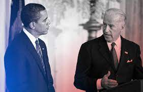

Former President Obama and Current President Biden. Photo by: *NBC News*

```r
knitr::opts_chunk$set(echo = TRUE, message = FALSE, warning = FALSE )
library(tidyverse)
library(here)
library(tidytext)
library(textdata)
library(pdftools)
library(ggwordcloud)
library(patchwork)

#Read in PDF's
obama <- pdf_text(here("data", "ObamaInaugural2009.pdf")) #Obama's Acceptance Speech in 2008
biden <- pdf_text(here("data", "BidenInaugural2021.pdf")) #Biden's Acceptance Speech in 2021
```

This report analyzes the inaugural speeches of the last two sitting Democratic presidents. The goal is to elucidate changes that have occurred within the party and politics between 2008 and 2021. The president’s speeches are compared through a series of analyses to better understand these changes. A word cloud is created to illustrate the top 15 most used words in each speech (generic words removed). Next, average sentiments in each speech are analyzed along an affinity scale. This scale visualizes overall the negative or positive manner of speech over a period of time. Speech pages were used as a proxy for time here. Last, these sentiments are mapped onto words denoting the messages within the speech.

**Data Citation:** January 20, 2009: Inaugural Address | Miller Center. (2016, October 20). https://millercenter.org/the-presidency/presidential-speeches/january-20-2009-inaugural-address

January 20, 2021: Inaugural Address | Miller Center. (2021, January 21). https://millercenter.org/the-presidency/presidential-speeches/january-20-2021-inaugural-address

## Word Wrangling

```r
#Creating dataframes: adding page numbers to line numbers
obama_lines <- data.frame(obama) %>%
  mutate(page = 1:n()) %>% #create a column names page that creates page numbers
  mutate(text_full = str_split(obama, pattern = '\\n')) %>% #splits pages into line by line, but keeps page number info. \\n looks for an actual \ and then a new line (\n)
  unnest(text_full) %>% #takes vector of string pieces we just made and creates a new line for each of those observations
  mutate(text_full = str_trim(text_full))

biden_lines <- data.frame(biden) %>%
  mutate(page = 1:n()) %>% #create a column names page that creates page numbers
  mutate(text_full = str_split(biden, pattern = '\\n')) %>% #splits pages into line by line, but keeps page number info. \\n looks for an actual \ and then a new line (\n)
  unnest(text_full) %>% #takes vector of string pieces we just made and creates a new line for each of those observations
  mutate(text_full = str_trim(text_full))

#Breaking dataframe into smaller pieces so that each word has its own line
obama_words <- obama_lines %>%
  unnest_tokens(word, text_full, token = 'words') %>% #tokenizes (counts) of something based what you give in the token argument. word here is a new column that is made. Data is pulled from obama
  select(-obama)

biden_words <- biden_lines %>%
  unnest_tokens(word, text_full, token = 'words') %>%
  select(-biden)

###Getting rid of America, American, Americans for better analysis
stop_america <- c("america", "american", "americans")
stop_america_df <- data.frame(stop_america, "word")
join_stop_america_df <- stop_america_df %>%
  mutate(word = stop_america) %>%
  select(-X.word.) %>%
  select(-stop_america)

# Getting rid of stop words
x <- stop_words #this removes those extra words we don't need (the, and, of, a)

obama_words_clean <- obama_words %>%
  anti_join(stop_words, by = 'word') %>%
  anti_join(join_stop_america_df, by = "word") %>%
  mutate(page = as.character(page))

biden_words_clean <- biden_words %>%
  anti_join(stop_words, by = 'word') %>%
  anti_join(join_stop_america_df, by = "word") %>%
  mutate(page = as.character(page))

#Looking at most common words
obama_wordcount <- obama_words_clean %>%
  count(word)
biden_wordcount <- biden_words_clean %>%
  count(word)

#Finding the most common 15 words

obama_top_15_words <- obama_wordcount %>%
  arrange(-n) %>% #by descending order of wordcount
  slice(1:15) %>% #cuts at 1-15 value in counts
  ungroup()

biden_top_15_words <- biden_wordcount %>%
  arrange(-n) %>% #by descending order of wordcount
  slice(1:15) %>% #cuts at 1-15 value in counts
  ungroup()
```